# Introduction to the rice package

# 5 Timescales

This package provides functions to translate values between the radiocarbon-relevant timescales of cal BP (calendar years before AD 1950), BC/AD (here we mean cal BC/AD, but shorten this to BC/AD), b2k (years before AD 2000, popular in the ice core community), C14, $\text{F} ^{14} \text{C}$, pMC and $\Delta ^{14} \text{C}$. The following Table lists the available functions:

| from\to | calBP | BCAD | b2k | C14 | F14C | pMC | Delta14C |
| --- | --- | --- | --- | --- | --- | --- | --- |
| **calBP** | - | `calBPtoBCAD` | `calBPtob2k` | `calBPtoC14` | `calBPtoF14C` | `calBPtopMC` | `calBPtoDelta14C` |
| **BCAD** | `BCADtocalBP` | - | `BCADtob2k` | `BCADtoC14` | `BCADtoF14C` | `BCADtopMC` | `BCADtoDelta14C` |
| **b2k** | `b2ktocalBP` | `b2ktoBCAD` | - | `b2ktoC14` | `b2ktoF14C` | `b2ktopMC` | `b2ktoDelta14C` |
| **C14** | `C14tocalBP` | `C14toBCAD` | `C14tob2k` | - | `C14toF14C` | `C14topMC` | `C14toDelta14C` |
| **F14C** | NA | NA | NA | `F14CtoC14` | - | `F14CtopMC` | `F14CtoDelta14C` |
| **pMC** | NA | NA | NA | `pMCtoC14` | `pMCtoF14C` | - | `pMCtoDelta14C` |
| **Delta14C** | NA | NA | NA | `Delta14CtoC14` | `Delta14CtoF14C` | `Delta14CtopMC` | - |

As an example of the above functions, the IntCal20 C14 age and error belonging to one or more cal BP or cal BCAD ages can be found (interpolating linearly where necessary):

```r
calBPtoC14(10.5)
```

```
##   C14 er
## 1 168 11
```

```r
BCADtoC14(1940:1950)
```

```
##    C14 er
## 1  170 11
## 2  174 11
## 3  178 11
## 4  181 11
## 5  185 11
## 6  188 11
## 7  190 11
## 8  193 11
## 9  195 11
## 10 197 11
## 11 199 11
```

To translate between cal BC/AD and cal BP ages, we can use (the last example avoids 0 BC/AD, since some calendars do not include zero):

```r
BCADtocalBP(2025)
```

```
## [1] -75
```

```r
BCADtocalBP(-1, zero=TRUE)
```

```
## [1] 1951
```

```r
BCADtocalBP(-1, zero=FALSE)
```

```
## [1] 1950
```

Delta14C ($\Delta$<sup>14</sup>C, a proxy for atmospheric <sup>14</sup>C concentration at *t* cal BP) can be transferred to F<sup>14</sup>C, and the other way around:

```r
Delta14CtoF14C(152, t=4000)
```

```
##        F14C
## 1 0.7100834
```

```r
F14CtoDelta14C(0.71, t=4000)
```

```
##   Delta14C
## 1 151.8647
```

This can also be done with C14 ages:

```r
C14toDelta14C(152, t=4000)
```

```
##   Delta14C
## 1 591.9353
```

```r
Delta14CtoC14(592, t=4000)
```

```
## [1] 151.6734
```

Although ages are most often expressed as 14C BP, radiocarbon labs calculate these ages from the measured F14C values. Since 14C BP = -8033 * ln(F), the distributions of especially older 14C ages and those with large errors become skewed, sometimes with their tails extending into infinite ages:

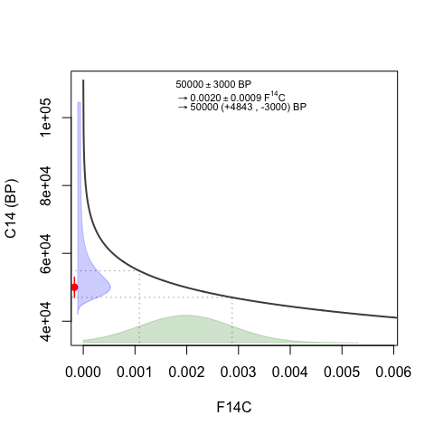

```r
draw.CF(50000, 3000)
```

Here’s a function to transform values between multiple timescales and visualise them:

```r
fromto(100, "calBP")
```

```
## 100 cal BP equals 1850 cal BC/AD, 124 14C BP, 0.98 F14C, 98.47 pMC, -3.33 Delta14C (cc=1)
```

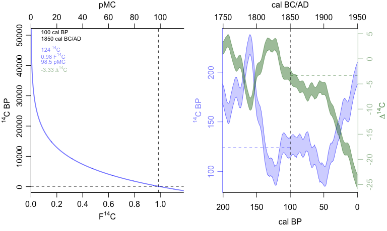

These functions can be used to investigate $\Delta^{14}\text{C}$ over time:

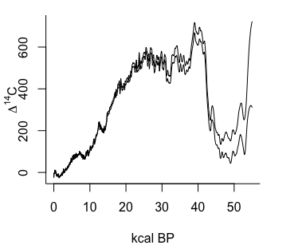

```r
x <- seq(0, 55e3, length=1e3)
cc <- calBPtoC14(x)
Dcc <- C14toDelta14C(cc[,1], cc[,2], x)

par(mar=c(4,3,1,3), bty="l")
plot(x/1e3, Dcc[,1]+Dcc[,2], type="l", xlab="kcal BP", ylab="")
mtext(expression(paste(Delta, ""^{14}, "C")), 2, 1.7)
lines(x/1e3, Dcc[,1]-Dcc[,2])
```

We can also use draw.ccurve to plot the IntCal20 curve as both C-14 years and $\Delta^{14}\text{C}$:

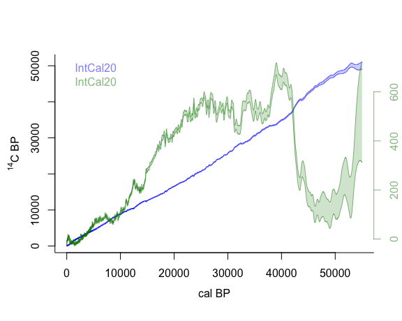

```r
draw.ccurve(cc2="IntCal20", timescale2="D", add.yaxis=TRUE)
```

# 6 Pooling dates

Sometimes, the same material is measured using multiple radiocarbon dates. If we can be sure that the dated material stems from one single age in time (e.g., multiple dates on the same single bone, or perhaps the cereal grains within one bowl which could be assumed to all stem from the same season), then we can check to which degree the dates agree using a Chi<sup>2</sup>-test (Ward & Wilson 1978)[^5]. If they do agree, then a pooled mean can be calculated. For example, take the Shroud of Turin, which was dated multiple times in three different labs:

```r
data(shroud)
shroud
```

```
##            ID   y er
## 1   AA-3367.1 591 30
## 2   AA-3367.2 690 35
## 3   AA-3367.3 606 41
## 4   AA-3367.4 701 33
## 5   Ox-2575.1 795 65
## 6   Ox-2575.2 730 45
## 7   Ox-2575.3 745 55
## 8  ETH-3883.1 733 61
## 9  ETH-3883.2 722 56
## 10 ETH-3883.3 635 57
## 11 ETH-3883.4 639 45
## 12 ETH-3883.5 679 51
```

Let’s check if we can pool the dates:

```r
pool(shroud$y,shroud$er)
```

```
## ! Scatter too large to calculate the pooled mean
## Chisq value: 20.697, p-value 0.037 < 0.05
```

```r
Zu <- grep("ETH", shroud$ID) # Zurich lab only
pool(shroud$y[Zu],shroud$er[Zu])
```

```
## pooled mean: 676.1 +- 23.7
## Chi2: 2.745, p-value 0.601 (>0.05, OK)
```

```
## [1] 676.1406  23.7443
```

Then the weighted mean can be calculated, with the error taken as the largest of the weighted uncertainty and the standard deviation:

```r
weighted_means(shroud$y[Zu],shroud$er[Zu])
```

```
## wmean 676.1, error is max of weighted uncertainty (23.7) & sdev (44.3): 44.3
```

```
## [1] 676.1  44.3
```

If it can indeed be safely assumed that all dates stem from the same (unknown) calendar year, then the age distribution of that single year can be plotted together with the individual calibrated ages:

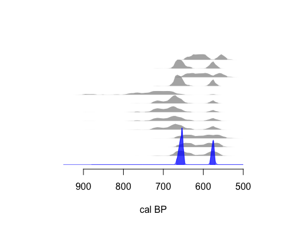

```
## point estimates (mean, median, mode and midpoint): 629, 652, 653 & 619 cal BP
```

```
## 95% hpd ranges: 583-570 (31.4%), 667-647 (63.5%)
```

```r
as.one(shroud$y,shroud$er)
```

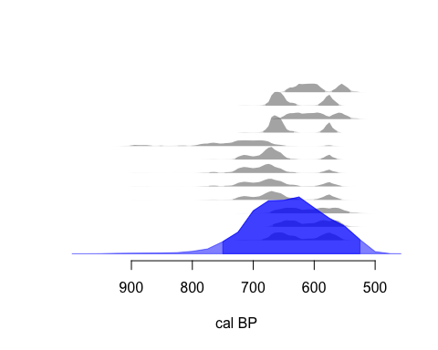

```
## point estimates (mean, median, mode and midpoint): 642, 628, 625 & 637 cal BP
```

```
## 95% hpd ranges: 757-516 (95%)
```

```r
as.bin(shroud$y,shroud$er, 100, move.by=25)
```

The spread of multiple calibrated dates can be visualised and summarised:

```r
spread(shroud$y,shroud$er)
```

```
## average spread: 65.8 calendar years (median 56.6)
## 95% range: 2.3 to 187.7
```

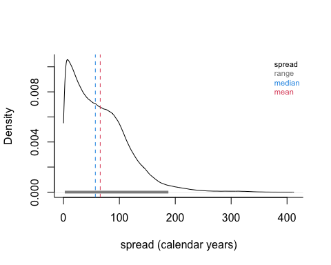

The time-span between two dates can be calculated (by sampling *n* pairs of random ages from both calibrated distributions and plotting the time-span for each pair):

```r
span(700, 20, 750, 20)
```

```
## average span: 32.5 calendar years (median 19)
## 95% range: 2.4 to 113.7
```

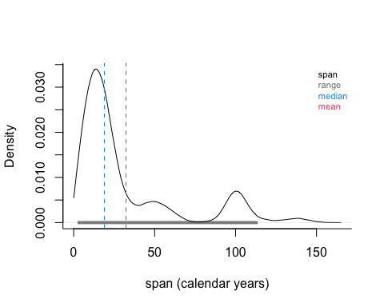

We can assess to what degree two calibrated distributions are overlapping (as the minimum calibrated height for each calendar year in a range). For example, imagine two dates from the same archaeological layer, a twig (3820 ± 40 C-14 BP, requiring calibration with IntCal20) and a marine shell (4430 ± 40 C-14 BP, requiring Marine20, with a regional marine offset of 90 ± 25). By what percentage do the two calibrated distributions overlap?

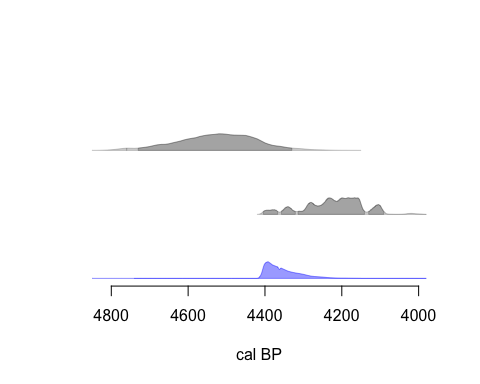

```
## overlap: 10.8%
```

```r
y <- c(3820, 4430+90)
er <- c(40, sqrt(40^2 + 25^2))
cc <- c(1,2)
overlap(y, er, cc=cc)
```

The calibrated ranges of radiocarbon dates can also be displayed in a table (either on a webbrowser or as Word document):

```r
data(shroud)
calibratable(shroud$y, shroud$er, shroud$ID, BCAD=TRUE)
```

| Lab ID | 14C BP (± sd) | 95% range (cal BC/AD) | 95% hpd ranges (cal BC/AD) |
| --- | --- | --- | --- |
| AA-3367.1 | 591 ± 30 | 1305 – 1408 | 1302 – 1368 (69.2%) 1380 – 1410 (25.8%) |
| AA-3367.2 | 690 ± 35 | 1272 – 1386 | 1270 – 1321 (62.8%) 1358 – 1390 (32.2%) |
| AA-3367.3 | 606 ± 41 | 1295 – 1410 | 1295 – 1410 (95%) |
| AA-3367.4 | 701 ± 33 | 1267 – 1383 | 1267 – 1317 (71%) 1360 – 1388 (24%) |
| Ox-2575.1 | 795 ± 65 | 1059 – 1323 | 1047 – 1083 (5.1%) 1095 – 1102 (0.5%) 1125 – 1140 (1.2%) 1148 – 1303 (86.8%) 1367 – 1380 (1.4%) |
| Ox-2575.2 | 730 ± 45 | 1223 – 1380 | 1220 – 1310 (83.3%) 1361 – 1387 (11.7%) |
| Ox-2575.3 | 745 ± 55 | 1182 – 1379 | 1178 – 1192 (2%) 1202 – 1320 (83.8%) 1359 – 1389 (9.2%) |
| ETH-3883.1 | 733 ± 61 | 1181 – 1385 | 1177 – 1193 (2%) 1201 – 1326 (77.1%) 1352 – 1394 (15.8%) |
| ETH-3883.2 | 722 ± 56 | 1212 – 1386 | 1216 – 1326 (74.9%) 1348 – 1395 (20.1%) |
| ETH-3883.3 | 635 ± 57 | 1279 – 1410 | 1278 – 1408 (95%) |
| ETH-3883.4 | 639 ± 45 | 1283 – 1400 | 1282 – 1398 (95%) |
| ETH-3883.5 | 679 ± 51 | 1252 – 1393 | 1265 – 1398 (95%) |

Calibration curve: IntCal20 (Reimer et al. 2020)

# 7 Contamination

To calculate the effect of contamination on radiocarbon ages, e.g. what age would be observed if material with a “true” radiocarbon age of 5000 ± 20 <sup>14</sup>C BP would be contaminated with 10% of modern carbon (F<sup>14</sup>C=1)?

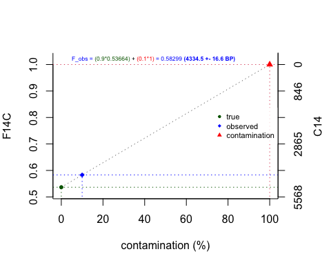

```
## True age in F14C: 0.53664 +- 0.00134
```

```
## Observed F14C: (0.9*0.53664) + (0.1*1) = 0.58299 +- 0.00121
```

```
## Observed C14 age: 4334.5 +- 16.6
```

```r
contaminate(5000, 20, 10, F.contam=1)
```

Or imagine that you measured a dinosaur bone, dating to far beyond the limit of radiocarbon dating, and the sample is very clean as it contains only 0.5% ± 0.1% modern contamination:

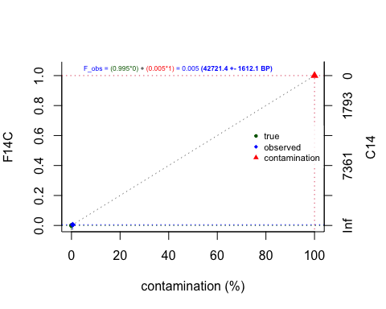

```
## True age in F14C: 0 +- 0
```

```
## Observed F14C: (0.995*0) + (0.005*1) = 0.005 +- 0.001
```

```
## Observed C14 age: 42721.4 +- 1612.1
```

```r
contaminate(66e6, 1e6, 0.5, 0.1, 1)
```

The other way round, e.g., inferring what would happen to an observed age if its assumed 10% modern contamination were to be removed:

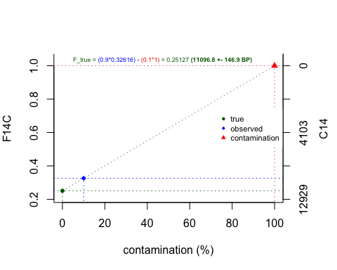

```
## Observed age as F14C: 0.32616 +- 0.00409
```

```
## True F14C: (0.9*0.32616) - (0.1*1) = 0.25127 +- 0.00459
```

```
## True C14 age: 11096.8 +- 146.9
```

```r
clean(9000, 100, 10)
```

We can also calculate the amount of contamination, or muck, required to ‘explain away’ certain ages. For example, one of the measurements of the Shroud of Turin dates to 591 ± 30 C14 BP. How much modern contamination would have to be inferred for the material to really date to, say, AD 40?

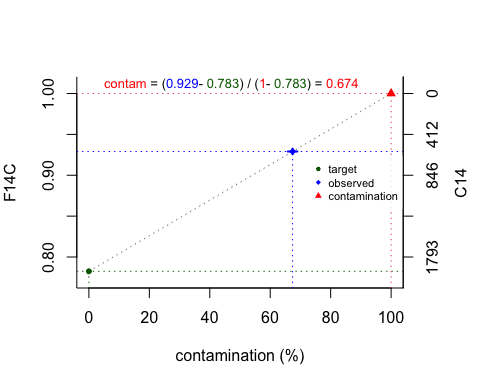

```
## Observed age: 591 +- 30 C14 BP (0.929+-0.003 F14C)
```

```
## Target age: 1970 C14 BP (0.783 F14C)
```

```
## Calculation: (0.929-0.783)/(1 - 0.783) = 0.67398
```

```
## Contamination required: 67.4+-1.6%
```

```r
muck(591, 30, BCADtoC14(40)[,1], 0, 1)
```

So we’d require the sample to have been contaminated by 67% modern carbon to still date to around AD 40. But what if the sample had been repaired in, say, the AD 1532 fire, thus adding material of an not-entirely-modern F14C value (i.e., taking into account both the atmospheric C-14 concentrations in AD 1532 and the fact that some of the C14 will have decayed since then)?

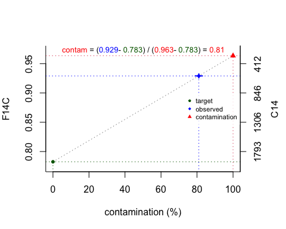

```
## Observed age: 591 +- 30 C14 BP (0.929+-0.003 F14C)
```

```
## Target age: 1970 C14 BP (0.783 F14C)
```

```
## Calculation: (0.929-0.783)/(0.963 - 0.783) = 0.80976
```

```
## Contamination required: 81+-2%
```

```r
perFaith <- BCADtoC14(40)
repairF <- BCADtoF14C(1532)
muck(591, 30, perFaith[,1], perFaith[,2], repairF[,1], repairF[,2])
```

This means that the dated sample would have to consist almost entirely of Medieval age material - which is exactly what was found by Damon et al. (1989)[^6].

What if we had a sample with a known percentage of contamination, and wanted to know the required activity (F14C) of said contamination to explain away a date? This can be done by providing the percentage contamination (e.g., 10%):

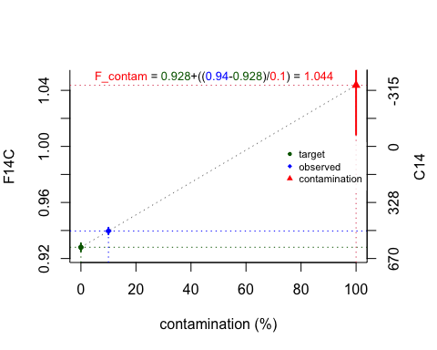

```
## Observed age: 500 +- 20 C14 BP (0.94+-0.002 F14C)
```

```
## Target age: 600 C14 BP (0.928 F14C)
```

```
## Calculation: 0.928 + ((0.94-0.928) / 0.1) = 1.044
```

```
## F of contamination: 1.044 +- 0.035
```

```r
muck(500, 20, 600, 25, perc.contam=10)
```

The effect of different levels of contamination can be visualised:

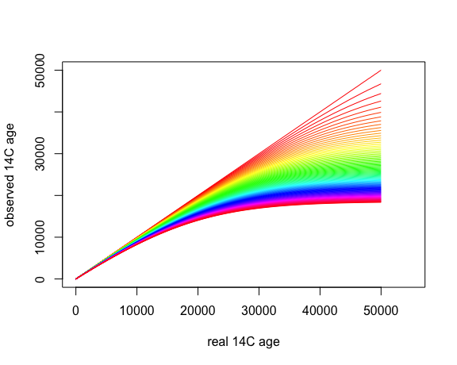

```r
real.14C <- seq(0, 50e3, length=200)
contam <- seq(0, 10, length=101) # 0 to 10% contamination
contam.col <- rainbow(length(contam))
plot(0, type="n", xlim=c(0, 55e3), xlab="real 14C age", ylim=range(real.14C), ylab="observed 14C age")
for (i in 1:length(contam)) {
  observed <- contaminate(real.14C, 0, contam[i], 0, 1, talk=FALSE, MC=FALSE)
  lines(real.14C, observed[,1], col = contam.col[i])
}
```

If that is too much code for you, try this function instead:

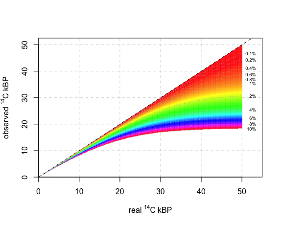

```r
draw.contamination()
```